# multiple_predictors

Sam Nicholes

2026-11-03

# Multivariable Models

## Multiple Predictors and Omitted Variable Bias

In a single variable model, the coefficient is inflated. The observed variance is being overly attributed to the single variable. Once covariates are included in the model, then variance is more accurately attributed among them.

```r
set.seed(2)
N <- 500 # sample size
skill <- rnorm(N) # skill variable
hours <- 2 + 0.9 * skill + rnorm(N, 0, 0.5) # hours variable, linearly related to skill
score <- 50 + 8 * skill + 1.5 * hours + rnorm(N, 0, 3) # score outcome variable, linearly related to skill and hours

round(c(naive    = coef(lm(score ~ hours))[2], # simple regression
        adjusted = coef(lm(score ~ hours + skill))[2], # adjusted regression
        truth    = 1.5), 3) # simulation true coefficient value for hours
```

```
##    naive.hours adjusted.hours          truth
##          8.553          1.515          1.500
```

Once skill is included in the mode, the coefficient for hours is more reflective of the parameter.

## Categorical Predictors

```r
set.seed(9)
plan  <- factor(rep(c("free", "pro", "ent"), each = 40),
                levels = c("free", "pro", "ent"))
spend <- c(rnorm(40, 50, 8), rnorm(40, 58, 8), rnorm(40, 66, 8))

round(coef(summary(lm(spend ~ plan))), 3)
```

```
##             Estimate Std. Error t value Pr(>|t|)
## (Intercept)   50.166      1.193  42.054        0
## planpro        7.398      1.687   4.385        0
## planent       14.373      1.687   8.520        0
```

### Inclusion of categorical predictors shifts the intercept, but doesn’t affect the slope

```r
set.seed(9)
plan  <- factor(rep(c("free", "pro", "ent"), each = 40),
                levels = c("free", "pro", "ent"))

# --- Part 1: your original model (factor only) -------------------------
spend0 <- c(rnorm(40, 50, 8), rnorm(40, 58, 8), rnorm(40, 66, 8))
fit0   <- lm(spend0 ~ plan)
round(coef(summary(fit0)), 3)
```

```
##             Estimate Std. Error t value Pr(>|t|)
## (Intercept)   50.166      1.193  42.054        0
## planpro        7.398      1.687   4.385        0
## planent       14.373      1.687   8.520        0
```

```r
# The dummy columns R builds behind the scenes (one row per plan)
model.matrix(~ plan)[c(1, 41, 81), ]
```

```
##    (Intercept) planpro planent
## 1            1       0       0
## 41           1       1       0
## 81           1       0       1
```

```r
# Intercept = mean of baseline (free); each dummy coefficient = shift from it
b0 <- coef(fit0)
rbind(from_coefs = c(free = b0[[1]],
                     pro  = b0[[1]] + b0[["planpro"]],
                     ent  = b0[[1]] + b0[["planent"]]),
      group_means = tapply(spend0, plan, mean))
```

```
##                 free      pro      ent
## from_coefs  50.16607 57.56377 64.53931
## group_means 50.16607 57.56377 64.53931
```

```r
# --- Part 2: add a continuous predictor so the shifts become lines -----
usage <- runif(120, 0, 10)
shift <- c(free = 0, pro = 8, ent = 16)          # true intercept shifts
spend <- 40 + 2 * usage + shift[as.character(plan)] + rnorm(120, 0, 4)

fit <- lm(spend ~ usage + plan)
round(coef(summary(fit)), 3)
```

```
##             Estimate Std. Error t value Pr(>|t|)
## (Intercept)   40.383      0.893  45.216        0
## usage          1.952      0.123  15.861        0
## planpro        7.490      0.884   8.473        0
## planent       16.186      0.885  18.289        0
```

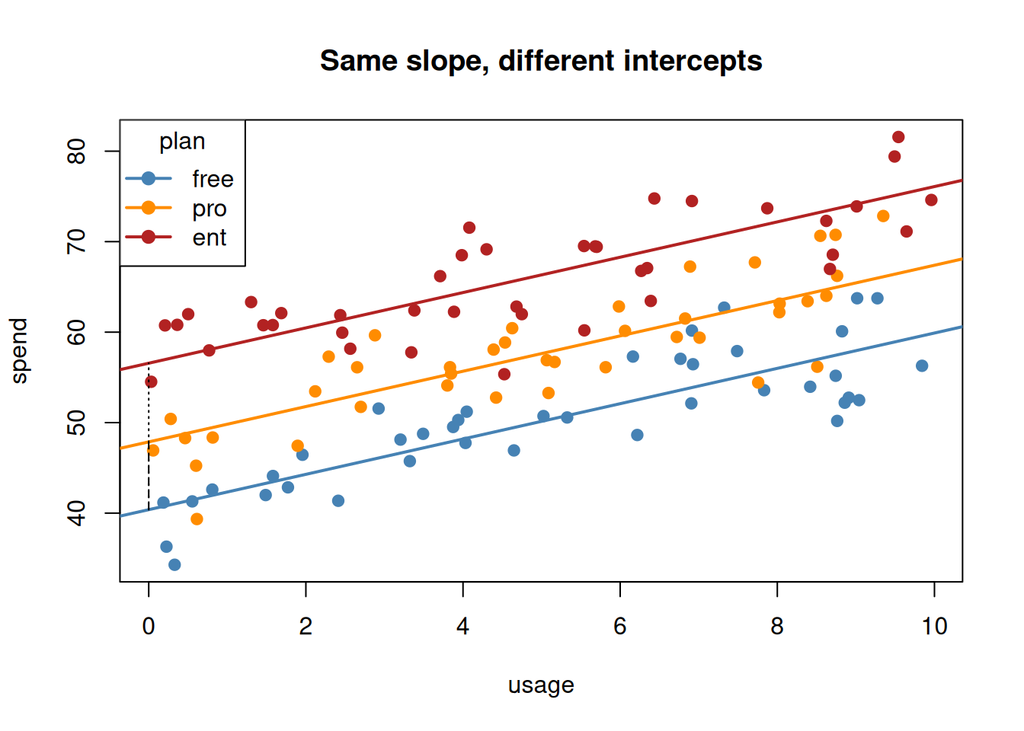

```r
b    <- coef(fit)
ints <- c(free = b[["(Intercept)"]],
          pro  = b[["(Intercept)"]] + b[["planpro"]],
          ent  = b[["(Intercept)"]] + b[["planent"]])

cols <- c(free = "steelblue", pro = "darkorange", ent = "firebrick")

plot(usage, spend, col = cols[as.character(plan)], pch = 19,
     xlab = "usage", ylab = "spend",
     main = "Same slope, different intercepts")
for (p in names(ints)) abline(a = ints[[p]], b = b[["usage"]],
                              col = cols[[p]], lwd = 2)
legend("topleft", legend = names(cols), col = cols, pch = 19, lwd = 2,
       title = "plan")

# Vertical gap between lines at any usage value = the dummy coefficient
segments(x0 = 0, y0 = ints[["free"]], y1 = ints[["pro"]], lty = 2)
segments(x0 = 0, y0 = ints[["free"]], y1 = ints[["ent"]], lty = 3)
```

## Interactions

```r
set.seed(12)
n <- 300
hours <- runif(n, 0, 10)
tier  <- factor(sample(c("basic", "premium"), n, replace = TRUE))
# The effect of hours is twice as large for premium users.
y <- 40 + 2 * hours + 5 * (tier == "premium") +
     2 * hours * (tier == "premium") + rnorm(n, 0, 4)

round(coef(summary(lm(y ~ hours * tier))), 3)
```

```
##                   Estimate Std. Error t value Pr(>|t|)
## (Intercept)         38.795      0.633  61.255        0
## hours                2.090      0.111  18.819        0
## tierpremium          6.982      0.866   8.066        0
## hours:tierpremium    1.779      0.151  11.762        0
```

```r
set.seed(12)
n <- 300
hours <- runif(n, 0, 10)
tier  <- factor(sample(c("basic", "premium"), n, replace = TRUE),
                levels = c("basic", "premium"))   # basic = reference level
# The effect of hours is twice as large for premium users.
y <- 40 + 2 * hours + 5 * (tier == "premium") +
     2 * hours * (tier == "premium") + rnorm(n, 0, 4)

# --- Part 1: your original interaction model ---------------------------
fit_int <- lm(y ~ hours * tier)
round(coef(summary(fit_int)), 3)
```

```
##                   Estimate Std. Error t value Pr(>|t|)
## (Intercept)         38.795      0.633  61.255        0
## hours                2.090      0.111  18.819        0
## tierpremium          6.982      0.866   8.066        0
## hours:tierpremium    1.779      0.151  11.762        0
```

```r
# The columns R builds: the interaction column is hours x dummy
rows <- c(which(tier == "basic")[1], which(tier == "premium")[1])
model.matrix(~ hours * tier)[rows, ]
```

```
##   (Intercept)     hours tierpremium hours:tierpremium
## 1           1 0.6936092           0         0.0000000
## 6           1 0.3389562           1         0.3389562
```

```r
# --- Part 2: rebuild each tier's line from the coefficients ------------
b <- coef(fit_int)
lines_from_coefs <- rbind(
  basic   = c(intercept = b[["(Intercept)"]],
              slope     = b[["hours"]]),
  premium = c(intercept = b[["(Intercept)"]] + b[["tierpremium"]],
              slope     = b[["hours"]] + b[["hours:tierpremium"]])
)
lines_from_coefs
```

```
##         intercept    slope
## basic    38.79525 2.090306
## premium  45.77767 3.869283
```

```r
# Check: fitting each tier separately gives the same intercepts and slopes
rbind(basic   = coef(lm(y ~ hours, subset = tier == "basic")),
      premium = coef(lm(y ~ hours, subset = tier == "premium")))
```

```
##         (Intercept)    hours
## basic      38.79525 2.090306
## premium    45.77767 3.869283
```

```r
# --- Part 3: the gap between tiers depends on hours --------------------
gap <- function(h) b[["tierpremium"]] + b[["hours:tierpremium"]] * h
data.frame(hours = c(0, 5, 10), premium_minus_basic = round(gap(c(0, 5, 10)), 2))
```

```
##   hours premium_minus_basic
## 1     0                6.98
## 2     5               15.88
## 3    10               24.77
```

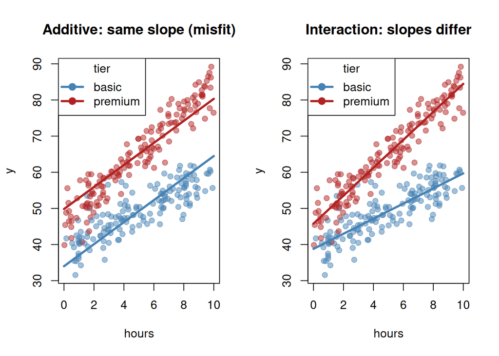

```r
# --- Part 4: additive (parallel) vs interaction model ------------------
fit_add <- lm(y ~ hours + tier)

cols <- c(basic = "steelblue", premium = "firebrick")
draw <- function(fit, title) {
  plot(hours, y, col = adjustcolor(cols[as.character(tier)], 0.5), pch = 19,
       xlab = "hours", ylab = "y", main = title)
  for (t in names(cols)) {
    nd <- data.frame(hours = c(0, 10), tier = factor(t, levels = levels(tier)))
    lines(nd$hours, predict(fit, nd), col = cols[[t]], lwd = 3)
  }
  legend("topleft", legend = names(cols), col = cols, lwd = 3, pch = 19,
         title = "tier")
}

par(mfrow = c(1, 2))
draw(fit_add, "Additive: same slope (misfit)")
draw(fit_int, "Interaction: slopes differ")
```

```r
par(mfrow = c(1, 1))

# Formal test: does allowing different slopes improve the fit?
anova(fit_add, fit_int)
```

```
## Analysis of Variance Table
##
## Model 1: y ~ hours + tier
## Model 2: y ~ hours * tier
##   Res.Df    RSS Df Sum of Sq      F    Pr(>F)
## 1    297 5952.9
## 2    296 4056.8  1    1896.1 138.35 < 2.2e-16 ***
## ---
## Signif. codes:  0 '***' 0.001 '**' 0.01 '*' 0.05 '.' 0.1 ' ' 1
```

**Additive graph (left)**: Forcing one shared slope produces parallel lines, so the model can only say that premium users sit a fixed amount higher at every value of hours. Because the true slopes differ (about 2 for basic, about 4 for premium), the single compromise slope is too steep for basic users and too shallow for premium users, and the points drift away from their lines at high hours. The constant gap it reports (roughly 15) is wrong almost everywhere, since the real gap grows from about 5 at zero hours to about 25 at ten.

$$y_i = \beta_0 + \beta_1\,\text{hours}_i + \beta_2\,\text{premium}_i +
\varepsilon_i$$

**Interaction graph (right)**: Giving each tier its own intercept and slope lets the lines fan apart, starting about 5 apart and widening by about 2 for every additional hour. Each line now runs through the middle of its own cloud of points, with no systematic over- or undershooting. The effect of hours is conditional on tier (about 2 for basic, about 4 for premium), so no single number describes “the effect of an hour” or “the premium difference” without saying where you are on the other variable.

$$y_i = \beta_0 + \beta_1\,\text{hours}_i + \beta_2\,\text{premium}_i +
\beta_3\,(\text{hours}_i \times \text{premium}_i) + \varepsilon_i,
\qquad \varepsilon_i \sim N(0, \sigma^2)$$

## Multiple Predictors and DFs

- Every additional predictor spends 1 DF.
- Predictors that are correlated with each other and inflate each other’s SE. This is multicolinearity. Look for large SEs; use VIF to detect multicolinearity.

```r
# Demonstrating multicollinearity in a linear model
set.seed(42)
n <- 100

# x1 and x2 are nearly the same variable (correlation ~0.99)
x1 <- rnorm(n)
x2 <- x1 + rnorm(n, sd = 0.1)

# True model: y = 2 + 3*x1 + 2*x2 + noise
y <- 2 + 3 * x1 + 2 * x2 + rnorm(n, sd = 2)
dat <- data.frame(y, x1, x2)

cat("Correlation between x1 and x2:", round(cor(x1, x2), 3), "\n\n")
```

```
## Correlation between x1 and x2: 0.996
```

```r
# 1. Full model: both predictors
full <- lm(y ~ x1 + x2, data = dat)
print(summary(full))
```

```
##
## Call:
## lm(formula = y ~ x1 + x2, data = dat)
##
## Residuals:
##     Min      1Q  Median      3Q     Max
## -5.1532 -1.3238 -0.1651  1.2741  5.0411
##
## Coefficients:
##             Estimate Std. Error t value Pr(>|t|)
## (Intercept)   2.0035     0.2038   9.831 3.11e-16 ***
## x1            1.0067     2.2691   0.444    0.658
## x2            3.7059     2.2545   1.644    0.103
## ---
## Signif. codes:  0 '***' 0.001 '**' 0.01 '*' 0.05 '.' 0.1 ' ' 1
##
## Residual standard error: 2.027 on 97 degrees of freedom
## Multiple R-squared:  0.8578, Adjusted R-squared:  0.8549
## F-statistic: 292.7 on 2 and 97 DF,  p-value: < 2.2e-16
```

```r
# 2. Each predictor alone
m1 <- lm(y ~ x1, data = dat)
m2 <- lm(y ~ x2, data = dat)
cat("\nx1 alone:\n"); print(round(summary(m1)$coefficients, 3))
```

```
##
## x1 alone:
```

```
##             Estimate Std. Error t value Pr(>|t|)
## (Intercept)    1.971      0.205   9.633        0
## x1             4.723      0.197  23.931        0
```

```r
cat("\nx2 alone:\n"); print(round(summary(m2)$coefficients, 3))
```

```
##
## x2 alone:
```

```
##             Estimate Std. Error t value Pr(>|t|)
## (Intercept)    2.013      0.202   9.966        0
## x2             4.702      0.194  24.289        0
```

```r
# 3. Variance Inflation Factor (computed by hand, no packages needed)
vif_x1 <- 1 / (1 - summary(lm(x1 ~ x2))$r.squared)
cat("\nVIF for x1 and x2:", round(vif_x1, 1), "\n")
```

```
##
## VIF for x1 and x2: 134.5
```

```r
# (With the car package: car::vif(full))

# 4. Instability: refit on bootstrap resamples and watch the coefficients swing
boot <- replicate(500, {
  d <- dat[sample(n, replace = TRUE), ]
  coef(lm(y ~ x1 + x2, data = d))[c("x1", "x2")]
})
cat("\nBootstrap SD of coefficients:\n")
```

```
##
## Bootstrap SD of coefficients:
```

```r
print(round(apply(boot, 1, sd), 2))
```

```
##   x1   x2
## 2.26 2.22
```

```r
cat("Correlation between the x1 and x2 estimates across resamples:",
    round(cor(boot[1, ], boot[2, ]), 3), "\n")
```

```
## Correlation between the x1 and x2 estimates across resamples: -0.996
```

```r
# Overall fit stays good even though individual coefficients are unreliable
cat("\nR-squared (full):", round(summary(full)$r.squared, 3),
    "| (x1 only):", round(summary(m1)$r.squared, 3), "\n")
```

```
##
## R-squared (full): 0.858 | (x1 only): 0.854
```